# Risk Factor Analysis

## Outcome Variable

**Outcome Variable:** haz

## Predictor Variables

**Intervention Variable:** enwast

**Adjustment Set:**

- arm
- sex
- W_mage
- meducyrs
- feducyrs
- vagbrth
- single
- brthmon
- W_parity
- delta_W_mage
- delta_meducyrs
- delta_feducyrs
- delta_vagbrth
- delta_single
- delta_brthmon
- delta_W_parity

## Stratifying Variables

The analysis was stratified on these variable(s):

- agecat
- studyid
- country

## Data Summary

| agecat | studyid | country | enwast | n_cell | n | outcome_variable |
| --- | --- | --- | --- | --- | --- | --- |
| Birth | CMC-V-BCS-2002 | INDIA | 0 | 75 | 87 | haz |
| Birth | CMC-V-BCS-2002 | INDIA | 1 | 12 | 87 | haz |
| Birth | CMIN | BANGLADESH | 0 | 15 | 19 | haz |
| Birth | CMIN | BANGLADESH | 1 | 4 | 19 | haz |
| Birth | COHORTS | GUATEMALA | 0 | 564 | 762 | haz |
| Birth | COHORTS | GUATEMALA | 1 | 198 | 762 | haz |
| Birth | COHORTS | INDIA | 0 | 5097 | 6231 | haz |
| Birth | COHORTS | INDIA | 1 | 1134 | 6231 | haz |
| Birth | COHORTS | PHILIPPINES | 0 | 2448 | 2910 | haz |
| Birth | COHORTS | PHILIPPINES | 1 | 462 | 2910 | haz |
| Birth | CONTENT | PERU | 0 | 2 | 2 | haz |
| Birth | CONTENT | PERU | 1 | 0 | 2 | haz |
| Birth | EE | PAKISTAN | 0 | 155 | 180 | haz |
| Birth | EE | PAKISTAN | 1 | 25 | 180 | haz |
| Birth | GMS-Nepal | NEPAL | 0 | 509 | 645 | haz |
| Birth | GMS-Nepal | NEPAL | 1 | 136 | 645 | haz |
| Birth | IRC | INDIA | 0 | 251 | 364 | haz |
| Birth | IRC | INDIA | 1 | 113 | 364 | haz |
| Birth | JiVitA-3 | BANGLADESH | 0 | 16041 | 18062 | haz |
| Birth | JiVitA-3 | BANGLADESH | 1 | 2021 | 18062 | haz |
| Birth | JiVitA-4 | BANGLADESH | 0 | 2157 | 2399 | haz |
| Birth | JiVitA-4 | BANGLADESH | 1 | 242 | 2399 | haz |
| Birth | Keneba | GAMBIA | 0 | 1102 | 1488 | haz |
| Birth | Keneba | GAMBIA | 1 | 386 | 1488 | haz |
| Birth | MAL-ED | BANGLADESH | 0 | 179 | 215 | haz |
| Birth | MAL-ED | BANGLADESH | 1 | 36 | 215 | haz |
| Birth | MAL-ED | BRAZIL | 0 | 60 | 62 | haz |
| Birth | MAL-ED | BRAZIL | 1 | 2 | 62 | haz |
| Birth | MAL-ED | INDIA | 0 | 40 | 45 | haz |
| Birth | MAL-ED | INDIA | 1 | 5 | 45 | haz |

[output cut: 134 more lines]

The following strata were considered:

- agecat: 24 months, studyid: CMC-V-BCS-2002, country: INDIA
- agecat: 24 months, studyid: CMIN, country: BANGLADESH
- agecat: 24 months, studyid: COHORTS, country: GUATEMALA
- agecat: 24 months, studyid: COHORTS, country: INDIA
- agecat: 24 months, studyid: COHORTS, country: PHILIPPINES
- agecat: 24 months, studyid: CONTENT, country: PERU
- agecat: 24 months, studyid: EE, country: PAKISTAN
- agecat: 24 months, studyid: GMS-Nepal, country: NEPAL
- agecat: 24 months, studyid: IRC, country: INDIA
- agecat: 24 months, studyid: JiVitA-3, country: BANGLADESH
- agecat: 24 months, studyid: JiVitA-4, country: BANGLADESH
- agecat: 24 months, studyid: Keneba, country: GAMBIA
- agecat: 24 months, studyid: LCNI-5, country: MALAWI
- agecat: 24 months, studyid: MAL-ED, country: BANGLADESH
- agecat: 24 months, studyid: MAL-ED, country: BRAZIL
- agecat: 24 months, studyid: MAL-ED, country: INDIA
- agecat: 24 months, studyid: MAL-ED, country: NEPAL
- agecat: 24 months, studyid: MAL-ED, country: PERU
- agecat: 24 months, studyid: MAL-ED, country: SOUTH AFRICA
- agecat: 24 months, studyid: MAL-ED, country: TANZANIA, UNITED REPUBLIC OF
- agecat: 24 months, studyid: NIH-Birth, country: BANGLADESH
- agecat: 24 months, studyid: NIH-Crypto, country: BANGLADESH
- agecat: 24 months, studyid: PROBIT, country: BELARUS
- agecat: 24 months, studyid: PROVIDE, country: BANGLADESH
- agecat: 24 months, studyid: TanzaniaChild2, country: TANZANIA, UNITED REPUBLIC OF
- agecat: 24 months, studyid: ZVITAMBO, country: ZIMBABWE
- agecat: 6 months, studyid: CMC-V-BCS-2002, country: INDIA
- agecat: 6 months, studyid: CMIN, country: BANGLADESH
- agecat: 6 months, studyid: COHORTS, country: GUATEMALA
- agecat: 6 months, studyid: COHORTS, country: INDIA
- agecat: 6 months, studyid: COHORTS, country: PHILIPPINES
- agecat: 6 months, studyid: CONTENT, country: PERU
- agecat: 6 months, studyid: EE, country: PAKISTAN
- agecat: 6 months, studyid: GMS-Nepal, country: NEPAL
- agecat: 6 months, studyid: Guatemala BSC, country: GUATEMALA
- agecat: 6 months, studyid: IRC, country: INDIA
- agecat: 6 months, studyid: JiVitA-3, country: BANGLADESH
- agecat: 6 months, studyid: JiVitA-4, country: BANGLADESH
- agecat: 6 months, studyid: Keneba, country: GAMBIA
- agecat: 6 months, studyid: LCNI-5, country: MALAWI
- agecat: 6 months, studyid: MAL-ED, country: BANGLADESH
- agecat: 6 months, studyid: MAL-ED, country: BRAZIL
- agecat: 6 months, studyid: MAL-ED, country: INDIA
- agecat: 6 months, studyid: MAL-ED, country: NEPAL
- agecat: 6 months, studyid: MAL-ED, country: PERU
- agecat: 6 months, studyid: MAL-ED, country: SOUTH AFRICA
- agecat: 6 months, studyid: MAL-ED, country: TANZANIA, UNITED REPUBLIC OF
- agecat: 6 months, studyid: NIH-Birth, country: BANGLADESH
- agecat: 6 months, studyid: NIH-Crypto, country: BANGLADESH
- agecat: 6 months, studyid: PROBIT, country: BELARUS
- agecat: 6 months, studyid: PROVIDE, country: BANGLADESH
- agecat: 6 months, studyid: ResPak, country: PAKISTAN
- agecat: 6 months, studyid: SAS-CompFeed, country: INDIA
- agecat: 6 months, studyid: SAS-FoodSuppl, country: INDIA
- agecat: 6 months, studyid: TanzaniaChild2, country: TANZANIA, UNITED REPUBLIC OF
- agecat: 6 months, studyid: ZVITAMBO, country: ZIMBABWE
- agecat: Birth, studyid: CMC-V-BCS-2002, country: INDIA
- agecat: Birth, studyid: CMIN, country: BANGLADESH
- agecat: Birth, studyid: COHORTS, country: GUATEMALA
- agecat: Birth, studyid: COHORTS, country: INDIA
- agecat: Birth, studyid: COHORTS, country: PHILIPPINES
- agecat: Birth, studyid: CONTENT, country: PERU
- agecat: Birth, studyid: EE, country: PAKISTAN
- agecat: Birth, studyid: GMS-Nepal, country: NEPAL
- agecat: Birth, studyid: IRC, country: INDIA
- agecat: Birth, studyid: JiVitA-3, country: BANGLADESH
- agecat: Birth, studyid: JiVitA-4, country: BANGLADESH
- agecat: Birth, studyid: Keneba, country: GAMBIA
- agecat: Birth, studyid: MAL-ED, country: BANGLADESH
- agecat: Birth, studyid: MAL-ED, country: BRAZIL
- agecat: Birth, studyid: MAL-ED, country: INDIA
- agecat: Birth, studyid: MAL-ED, country: NEPAL
- agecat: Birth, studyid: MAL-ED, country: PERU
- agecat: Birth, studyid: MAL-ED, country: SOUTH AFRICA
- agecat: Birth, studyid: MAL-ED, country: TANZANIA, UNITED REPUBLIC OF
- agecat: Birth, studyid: NIH-Birth, country: BANGLADESH
- agecat: Birth, studyid: NIH-Crypto, country: BANGLADESH
- agecat: Birth, studyid: PROBIT, country: BELARUS
- agecat: Birth, studyid: PROVIDE, country: BANGLADESH
- agecat: Birth, studyid: ResPak, country: PAKISTAN
- agecat: Birth, studyid: SAS-CompFeed, country: INDIA
- agecat: Birth, studyid: ZVITAMBO, country: ZIMBABWE

### Dropped Strata

Some strata were dropped due to rare outcomes:

- agecat: Birth, studyid: CMIN, country: BANGLADESH
- agecat: Birth, studyid: CONTENT, country: PERU
- agecat: Birth, studyid: MAL-ED, country: BRAZIL
- agecat: Birth, studyid: MAL-ED, country: NEPAL
- agecat: Birth, studyid: MAL-ED, country: TANZANIA, UNITED REPUBLIC OF
- agecat: Birth, studyid: ResPak, country: PAKISTAN
- agecat: 6 months, studyid: CONTENT, country: PERU
- agecat: 6 months, studyid: MAL-ED, country: TANZANIA, UNITED REPUBLIC OF
- agecat: 24 months, studyid: CONTENT, country: PERU
- agecat: 24 months, studyid: MAL-ED, country: PERU
- agecat: 24 months, studyid: MAL-ED, country: TANZANIA, UNITED REPUBLIC OF
- agecat: 24 months, studyid: TanzaniaChild2, country: TANZANIA, UNITED REPUBLIC OF

## Methods Detail

We’re interested in the causal parameters $E[Y_a]$ for all values of $a \in \mathcal{A}$. These parameters represent the mean outcome if, possibly contrary to fact, we intervened to set all units to have $A=a$. Under the randomization and positivity assumptions, these are identified by the statistical parameters $\psi_a=E_W[E_{Y|A,W}(Y|A=a,W)]$. In addition, we’re interested in the mean of $Y$, $E[Y]$ under no intervention (the observed mean). We will estimate these parameters by using SuperLearner to fit the relevant likelihood factors – $E_{Y|A,W}(Y|A=a,W)$ and $p(A=a|W)$, and then updating our likelihood fit using a joint TMLE.

For unadjusted analyses ($W=\{\}$), initial likelihoods were estimated using Lrnr_glm to estimate the simple $E(Y|A)$ and Lrnr_mean to estimate $p(A)$. For adjusted analyses, a small library containing Lrnr_glmnet, Lrnr_xgboost, and Lrnr_mean was used.

Having estimated these parameters, we will then use the delta method to estimate relative risks and attributable risks relative to a prespecified baseline level of $A$.

# Results Detail

## Results Plots

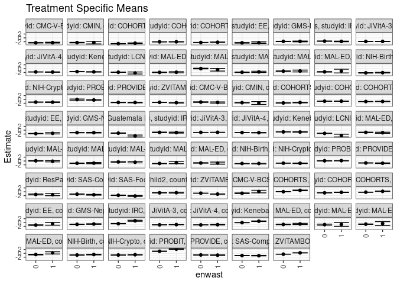

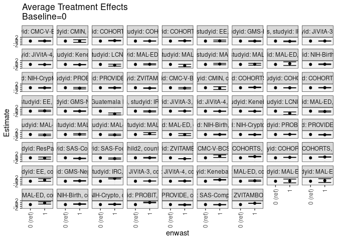

[figure not shown]

## Results Table

### Parameter: TSM

| agecat | studyid | country | intervention_level | baseline_level | estimate | ci_lower | ci_upper |
| --- | --- | --- | --- | --- | --- | --- | --- |
| Birth | CMC-V-BCS-2002 | INDIA | 0 | NA | -0.7854036 | -0.9718860 | -0.5989213 |
| Birth | CMC-V-BCS-2002 | INDIA | 1 | NA | 0.0995573 | -0.5708187 | 0.7699332 |
| Birth | COHORTS | GUATEMALA | 0 | NA | 0.0441935 | -0.0446110 | 0.1329981 |
| Birth | COHORTS | GUATEMALA | 1 | NA | 0.7234487 | 0.5772211 | 0.8696762 |
| Birth | COHORTS | INDIA | 0 | NA | -0.5540904 | -0.5805079 | -0.5276728 |
| Birth | COHORTS | INDIA | 1 | NA | -0.2976662 | -0.3630943 | -0.2322382 |
| Birth | COHORTS | PHILIPPINES | 0 | NA | -0.2199584 | -0.2562234 | -0.1836934 |
| Birth | COHORTS | PHILIPPINES | 1 | NA | 0.2314706 | 0.1272858 | 0.3356553 |
| Birth | EE | PAKISTAN | 0 | NA | -1.3221410 | -1.4630227 | -1.1812593 |
| Birth | EE | PAKISTAN | 1 | NA | -0.6851143 | -1.3832291 | 0.0130005 |
| Birth | GMS-Nepal | NEPAL | 0 | NA | -0.9509086 | -1.0273531 | -0.8744642 |
| Birth | GMS-Nepal | NEPAL | 1 | NA | -0.7740706 | -0.9349981 | -0.6131431 |
| Birth | IRC | INDIA | 0 | NA | -0.5972699 | -0.7180433 | -0.4764964 |
| Birth | IRC | INDIA | 1 | NA | 0.9134021 | 0.6270110 | 1.1997933 |
| Birth | JiVitA-3 | BANGLADESH | 0 | NA | -1.1898087 | -1.2045532 | -1.1750641 |
| Birth | JiVitA-3 | BANGLADESH | 1 | NA | -1.0893487 | -1.1380773 | -1.0406202 |
| Birth | JiVitA-4 | BANGLADESH | 0 | NA | -1.2287232 | -1.2702190 | -1.1872274 |
| Birth | JiVitA-4 | BANGLADESH | 1 | NA | -1.1280341 | -1.2864349 | -0.9696333 |
| Birth | Keneba | GAMBIA | 0 | NA | -0.0581107 | -0.1159245 | -0.0002969 |
| Birth | Keneba | GAMBIA | 1 | NA | 0.6970340 | 0.5685990 | 0.8254689 |
| Birth | MAL-ED | BANGLADESH | 0 | NA | -0.9991428 | -1.1277640 | -0.8705216 |
| Birth | MAL-ED | BANGLADESH | 1 | NA | -0.7429774 | -1.0553922 | -0.4305626 |
| Birth | MAL-ED | INDIA | 0 | NA | -1.0995000 | -1.3601155 | -0.8388845 |
| Birth | MAL-ED | INDIA | 1 | NA | -0.9800000 | -1.9772048 | 0.0172048 |
| Birth | MAL-ED | PERU | 0 | NA | -0.8421525 | -0.9539315 | -0.7303735 |
| Birth | MAL-ED | PERU | 1 | NA | -0.5260000 | -1.5481689 | 0.4961689 |
| Birth | MAL-ED | SOUTH AFRICA | 0 | NA | -0.6503195 | -0.8182427 | -0.4823963 |
| Birth | MAL-ED | SOUTH AFRICA | 1 | NA | 0.2207172 | -0.3640603 | 0.8054947 |
| Birth | NIH-Birth | BANGLADESH | 0 | NA | -0.8870703 | -0.9724798 | -0.8016608 |
| Birth | NIH-Birth | BANGLADESH | 1 | NA | -0.6525688 | -0.8364920 | -0.4686455 |

[output cut: 110 more lines]

### Parameter: E(Y)

| agecat | studyid | country | intervention_level | baseline_level | estimate | ci_lower | ci_upper |
| --- | --- | --- | --- | --- | --- | --- | --- |
| Birth | CMC-V-BCS-2002 | INDIA | NA | NA | -0.8194253 | -1.0062738 | -0.6325768 |
| Birth | COHORTS | GUATEMALA | NA | NA | 0.2220341 | 0.1435838 | 0.3004845 |
| Birth | COHORTS | INDIA | NA | NA | -0.5071369 | -0.5319444 | -0.4823294 |
| Birth | COHORTS | PHILIPPINES | NA | NA | -0.1490962 | -0.1843045 | -0.1138879 |
| Birth | EE | PAKISTAN | NA | NA | -1.2383333 | -1.3946042 | -1.0820625 |
| Birth | GMS-Nepal | NEPAL | NA | NA | -0.9117209 | -0.9811840 | -0.8422578 |
| Birth | IRC | INDIA | NA | NA | -0.1131044 | -0.2551572 | 0.0289484 |
| Birth | JiVitA-3 | BANGLADESH | NA | NA | -1.1782283 | -1.1929469 | -1.1635098 |
| Birth | JiVitA-4 | BANGLADESH | NA | NA | -1.2196123 | -1.2608853 | -1.1783394 |
| Birth | Keneba | GAMBIA | NA | NA | 0.1338508 | 0.0777935 | 0.1899081 |
| Birth | MAL-ED | BANGLADESH | NA | NA | -0.9625581 | -1.0817638 | -0.8433525 |
| Birth | MAL-ED | INDIA | NA | NA | -1.0862222 | -1.3432542 | -0.8291902 |
| Birth | MAL-ED | PERU | NA | NA | -0.8352193 | -0.9473216 | -0.7231170 |
| Birth | MAL-ED | SOUTH AFRICA | NA | NA | -0.5594215 | -0.7261377 | -0.3927053 |
| Birth | NIH-Birth | BANGLADESH | NA | NA | -0.8156034 | -0.8972149 | -0.7339920 |
| Birth | NIH-Crypto | BANGLADESH | NA | NA | -0.8487377 | -0.9161997 | -0.7812758 |
| Birth | PROBIT | BELARUS | NA | NA | 1.3137865 | 1.1546333 | 1.4729398 |
| Birth | PROVIDE | BANGLADESH | NA | NA | -0.8579887 | -0.9311892 | -0.7847883 |
| Birth | SAS-CompFeed | INDIA | NA | NA | -1.1641176 | -1.2153187 | -1.1129166 |
| Birth | ZVITAMBO | ZIMBABWE | NA | NA | -0.3412145 | -0.3591726 | -0.3232564 |
| 6 months | CMC-V-BCS-2002 | INDIA | NA | NA | -1.4223508 | -1.5654032 | -1.2792984 |
| 6 months | CMIN | BANGLADESH | NA | NA | -1.7090230 | -1.8439050 | -1.5741410 |
| 6 months | COHORTS | GUATEMALA | NA | NA | -1.7950277 | -1.8646284 | -1.7254271 |
| 6 months | COHORTS | INDIA | NA | NA | -0.9241887 | -0.9514678 | -0.8969095 |
| 6 months | COHORTS | PHILIPPINES | NA | NA | -1.0928731 | -1.1347142 | -1.0510321 |
| 6 months | EE | PAKISTAN | NA | NA | -1.7873630 | -1.9021295 | -1.6725965 |
| 6 months | GMS-Nepal | NEPAL | NA | NA | -1.2753093 | -1.3514861 | -1.1991326 |
| 6 months | Guatemala BSC | GUATEMALA | NA | NA | -1.5619008 | -1.6727702 | -1.4510313 |
| 6 months | IRC | INDIA | NA | NA | -1.1707373 | -1.3023712 | -1.0391035 |
| 6 months | JiVitA-3 | BANGLADESH | NA | NA | -1.1254416 | -1.1482406 | -1.1026426 |
| 6 months | JiVitA-4 | BANGLADESH | NA | NA | -1.2464966 | -1.2832103 | -1.2097829 |
| 6 months | Keneba | GAMBIA | NA | NA | -0.8918017 | -0.9392551 | -0.8443483 |
| 6 months | LCNI-5 | MALAWI | NA | NA | -1.6601907 | -1.7297701 | -1.5906113 |
| 6 months | MAL-ED | BANGLADESH | NA | NA | -1.1545706 | -1.2720635 | -1.0370777 |
| 6 months | MAL-ED | BRAZIL | NA | NA | 0.0820017 | -0.0652646 | 0.2292679 |
| 6 months | MAL-ED | INDIA | NA | NA | -1.1907471 | -1.3084496 | -1.0730447 |
| 6 months | MAL-ED | NEPAL | NA | NA | -0.5356897 | -0.6466309 | -0.4247484 |
| 6 months | MAL-ED | PERU | NA | NA | -1.3000971 | -1.4087542 | -1.1914400 |
| 6 months | MAL-ED | SOUTH AFRICA | NA | NA | -1.0492424 | -1.1743146 | -0.9241702 |
| 6 months | NIH-Birth | BANGLADESH | NA | NA | -1.3447001 | -1.4316348 | -1.2577653 |
| 6 months | NIH-Crypto | BANGLADESH | NA | NA | -1.1560014 | -1.2261266 | -1.0858763 |
| 6 months | PROBIT | BELARUS | NA | NA | 0.0987124 | 0.0071839 | 0.1902410 |
| 6 months | PROVIDE | BANGLADESH | NA | NA | -1.0728671 | -1.1465641 | -0.9991701 |
| 6 months | ResPak | PAKISTAN | NA | NA | -1.4274196 | -1.6382670 | -1.2165722 |
| 6 months | SAS-CompFeed | INDIA | NA | NA | -1.2781121 | -1.3694457 | -1.1867786 |
| 6 months | SAS-FoodSuppl | INDIA | NA | NA | -1.8986842 | -2.0118892 | -1.7854792 |
| 6 months | TanzaniaChild2 | TANZANIA, UNITED REPUBLIC OF | NA | NA | -0.5424220 | -0.5912180 | -0.4936261 |
| 6 months | ZVITAMBO | ZIMBABWE | NA | NA | -0.8157359 | -0.8414876 | -0.7899842 |
| 24 months | CMC-V-BCS-2002 | INDIA | NA | NA | -2.5559249 | -2.6552739 | -2.4565759 |
| 24 months | CMIN | BANGLADESH | NA | NA | -2.4877155 | -2.6168325 | -2.3585986 |
| 24 months | COHORTS | GUATEMALA | NA | NA | -2.9946835 | -3.0601854 | -2.9291817 |
| 24 months | COHORTS | INDIA | NA | NA | -2.0741479 | -2.1071054 | -2.0411904 |
| 24 months | COHORTS | PHILIPPINES | NA | NA | -2.3841755 | -2.4295300 | -2.3388211 |
| 24 months | EE | PAKISTAN | NA | NA | -2.5941727 | -2.7436756 | -2.4446699 |
| 24 months | GMS-Nepal | NEPAL | NA | NA | -1.8435238 | -1.9304004 | -1.7566473 |
| 24 months | IRC | INDIA | NA | NA | -1.7639600 | -1.8601530 | -1.6677669 |
| 24 months | JiVitA-3 | BANGLADESH | NA | NA | -1.8772038 | -1.9062064 | -1.8482013 |
| 24 months | JiVitA-4 | BANGLADESH | NA | NA | -1.7182341 | -1.7544244 | -1.6820437 |
| 24 months | Keneba | GAMBIA | NA | NA | -1.5730887 | -1.6234321 | -1.5227452 |
| 24 months | LCNI-5 | MALAWI | NA | NA | -1.8861485 | -1.9671802 | -1.8051169 |
| 24 months | MAL-ED | BANGLADESH | NA | NA | -1.9287562 | -2.0568859 | -1.8006265 |
| 24 months | MAL-ED | BRAZIL | NA | NA | 0.0113750 | -0.1608859 | 0.1836359 |
| 24 months | MAL-ED | INDIA | NA | NA | -1.8697758 | -1.9956076 | -1.7439440 |
| 24 months | MAL-ED | NEPAL | NA | NA | -1.2990889 | -1.4193577 | -1.1788201 |
| 24 months | MAL-ED | SOUTH AFRICA | NA | NA | -1.6435830 | -1.7787856 | -1.5083803 |
| 24 months | NIH-Birth | BANGLADESH | NA | NA | -2.1580827 | -2.2606216 | -2.0555438 |
| 24 months | NIH-Crypto | BANGLADESH | NA | NA | -1.4121200 | -1.4955578 | -1.3286822 |
| 24 months | PROBIT | BELARUS | NA | NA | -0.1437293 | -0.4231910 | 0.1357324 |
| 24 months | PROVIDE | BANGLADESH | NA | NA | -1.5877105 | -1.6705437 | -1.5048773 |
| 24 months | ZVITAMBO | ZIMBABWE | NA | NA | -1.5460133 | -1.6038691 | -1.4881575 |

### Parameter: ATE

| agecat | studyid | country | intervention_level | baseline_level | estimate | ci_lower | ci_upper |
| --- | --- | --- | --- | --- | --- | --- | --- |
| Birth | CMC-V-BCS-2002 | INDIA | 0 | 0 | 0.0000000 | 0.0000000 | 0.0000000 |
| Birth | CMC-V-BCS-2002 | INDIA | 1 | 0 | 0.8849609 | 0.1906762 | 1.5792456 |
| Birth | COHORTS | GUATEMALA | 0 | 0 | 0.0000000 | 0.0000000 | 0.0000000 |
| Birth | COHORTS | GUATEMALA | 1 | 0 | 0.6792551 | 0.5082700 | 0.8502402 |
| Birth | COHORTS | INDIA | 0 | 0 | 0.0000000 | 0.0000000 | 0.0000000 |
| Birth | COHORTS | INDIA | 1 | 0 | 0.2564241 | 0.1860105 | 0.3268378 |
| Birth | COHORTS | PHILIPPINES | 0 | 0 | 0.0000000 | 0.0000000 | 0.0000000 |
| Birth | COHORTS | PHILIPPINES | 1 | 0 | 0.4514290 | 0.3415406 | 0.5613173 |
| Birth | EE | PAKISTAN | 0 | 0 | 0.0000000 | 0.0000000 | 0.0000000 |
| Birth | EE | PAKISTAN | 1 | 0 | 0.6370267 | -0.0786346 | 1.3526880 |
| Birth | GMS-Nepal | NEPAL | 0 | 0 | 0.0000000 | 0.0000000 | 0.0000000 |
| Birth | GMS-Nepal | NEPAL | 1 | 0 | 0.1768380 | -0.0005828 | 0.3542589 |
| Birth | IRC | INDIA | 0 | 0 | 0.0000000 | 0.0000000 | 0.0000000 |
| Birth | IRC | INDIA | 1 | 0 | 1.5106720 | 1.1992193 | 1.8221247 |
| Birth | JiVitA-3 | BANGLADESH | 0 | 0 | 0.0000000 | 0.0000000 | 0.0000000 |
| Birth | JiVitA-3 | BANGLADESH | 1 | 0 | 0.1004599 | 0.0511232 | 0.1497967 |
| Birth | JiVitA-4 | BANGLADESH | 0 | 0 | 0.0000000 | 0.0000000 | 0.0000000 |
| Birth | JiVitA-4 | BANGLADESH | 1 | 0 | 0.1006890 | -0.0610533 | 0.2624314 |
| Birth | Keneba | GAMBIA | 0 | 0 | 0.0000000 | 0.0000000 | 0.0000000 |
| Birth | Keneba | GAMBIA | 1 | 0 | 0.7551447 | 0.6144590 | 0.8958303 |
| Birth | MAL-ED | BANGLADESH | 0 | 0 | 0.0000000 | 0.0000000 | 0.0000000 |
| Birth | MAL-ED | BANGLADESH | 1 | 0 | 0.2561654 | -0.0843402 | 0.5966709 |
| Birth | MAL-ED | INDIA | 0 | 0 | 0.0000000 | 0.0000000 | 0.0000000 |
| Birth | MAL-ED | INDIA | 1 | 0 | 0.1195000 | -0.9111978 | 1.1501978 |
| Birth | MAL-ED | PERU | 0 | 0 | 0.0000000 | 0.0000000 | 0.0000000 |
| Birth | MAL-ED | PERU | 1 | 0 | 0.3161525 | -0.7121101 | 1.3444150 |
| Birth | MAL-ED | SOUTH AFRICA | 0 | 0 | 0.0000000 | 0.0000000 | 0.0000000 |
| Birth | MAL-ED | SOUTH AFRICA | 1 | 0 | 0.8710367 | 0.2614553 | 1.4806181 |
| Birth | NIH-Birth | BANGLADESH | 0 | 0 | 0.0000000 | 0.0000000 | 0.0000000 |
| Birth | NIH-Birth | BANGLADESH | 1 | 0 | 0.2345016 | 0.0318092 | 0.4371940 |

[output cut: 110 more lines]

### Parameter: PAR

| agecat | studyid | country | intervention_level | baseline_level | estimate | ci_lower | ci_upper |
| --- | --- | --- | --- | --- | --- | --- | --- |
| Birth | CMC-V-BCS-2002 | INDIA | 0 | NA | -0.0340217 | -0.1339000 | 0.0658567 |
| Birth | COHORTS | GUATEMALA | 0 | NA | 0.1778406 | 0.1289359 | 0.2267453 |
| Birth | COHORTS | INDIA | 0 | NA | 0.0469535 | 0.0339995 | 0.0599075 |
| Birth | COHORTS | PHILIPPINES | 0 | NA | 0.0708622 | 0.0526348 | 0.0890896 |
| Birth | EE | PAKISTAN | 0 | NA | 0.0838077 | -0.0192390 | 0.1868543 |
| Birth | GMS-Nepal | NEPAL | 0 | NA | 0.0391877 | 0.0015425 | 0.0768329 |
| Birth | IRC | INDIA | 0 | NA | 0.4841655 | 0.3615218 | 0.6068092 |
| Birth | JiVitA-3 | BANGLADESH | 0 | NA | 0.0115803 | 0.0061459 | 0.0170148 |
| Birth | JiVitA-4 | BANGLADESH | 0 | NA | 0.0091108 | -0.0072763 | 0.0254979 |
| Birth | Keneba | GAMBIA | 0 | NA | 0.1919615 | 0.1526791 | 0.2312440 |
| Birth | MAL-ED | BANGLADESH | 0 | NA | 0.0365846 | -0.0238865 | 0.0970558 |
| Birth | MAL-ED | INDIA | 0 | NA | 0.0132778 | -0.1017806 | 0.1283361 |
| Birth | MAL-ED | PERU | 0 | NA | 0.0069332 | -0.0194696 | 0.0333360 |
| Birth | MAL-ED | SOUTH AFRICA | 0 | NA | 0.0908980 | 0.0115897 | 0.1702063 |
| Birth | NIH-Birth | BANGLADESH | 0 | NA | 0.0714669 | 0.0107151 | 0.1322187 |
| Birth | NIH-Crypto | BANGLADESH | 0 | NA | 0.0440030 | 0.0020989 | 0.0859071 |
| Birth | PROBIT | BELARUS | 0 | NA | 0.2401874 | 0.1415576 | 0.3388172 |
| Birth | PROVIDE | BANGLADESH | 0 | NA | -0.0086554 | -0.0530134 | 0.0357026 |
| Birth | SAS-CompFeed | INDIA | 0 | NA | -0.0046060 | -0.0166783 | 0.0074663 |
| Birth | ZVITAMBO | ZIMBABWE | 0 | NA | 0.1179523 | 0.1070944 | 0.1288102 |
| 6 months | CMC-V-BCS-2002 | INDIA | 0 | NA | -0.0330208 | -0.1217209 | 0.0556794 |
| 6 months | CMIN | BANGLADESH | 0 | NA | -0.0128930 | -0.0546723 | 0.0288864 |
| 6 months | COHORTS | GUATEMALA | 0 | NA | 0.0393494 | 0.0061607 | 0.0725381 |
| 6 months | COHORTS | INDIA | 0 | NA | -0.0005280 | -0.0138225 | 0.0127665 |
| 6 months | COHORTS | PHILIPPINES | 0 | NA | 0.0059766 | -0.0126011 | 0.0245544 |
| 6 months | EE | PAKISTAN | 0 | NA | -0.0031483 | -0.0450956 | 0.0387990 |
| 6 months | GMS-Nepal | NEPAL | 0 | NA | 0.0007835 | -0.0384350 | 0.0400021 |
| 6 months | Guatemala BSC | GUATEMALA | 0 | NA | -0.0297734 | -0.0564518 | -0.0030950 |
| 6 months | IRC | INDIA | 0 | NA | -0.0359573 | -0.1255727 | 0.0536580 |
| 6 months | JiVitA-3 | BANGLADESH | 0 | NA | 0.0032597 | -0.0034754 | 0.0099948 |
| 6 months | JiVitA-4 | BANGLADESH | 0 | NA | -0.0057401 | -0.0168717 | 0.0053915 |
| 6 months | Keneba | GAMBIA | 0 | NA | -0.0102879 | -0.0344476 | 0.0138718 |
| 6 months | LCNI-5 | MALAWI | 0 | NA | -0.0096304 | -0.0272691 | 0.0080082 |
| 6 months | MAL-ED | BANGLADESH | 0 | NA | -0.0218820 | -0.0809374 | 0.0371734 |
| 6 months | MAL-ED | BRAZIL | 0 | NA | -0.0077032 | -0.0222800 | 0.0068736 |
| 6 months | MAL-ED | INDIA | 0 | NA | -0.0030374 | -0.0665932 | 0.0605183 |
| 6 months | MAL-ED | NEPAL | 0 | NA | -0.0302720 | -0.0779920 | 0.0174480 |
| 6 months | MAL-ED | PERU | 0 | NA | 0.0081500 | -0.0069525 | 0.0232525 |
| 6 months | MAL-ED | SOUTH AFRICA | 0 | NA | 0.0042870 | -0.0311072 | 0.0396813 |
| 6 months | NIH-Birth | BANGLADESH | 0 | NA | -0.0099434 | -0.0680036 | 0.0481168 |
| 6 months | NIH-Crypto | BANGLADESH | 0 | NA | -0.0080765 | -0.0511623 | 0.0350093 |
| 6 months | PROBIT | BELARUS | 0 | NA | 0.0069763 | -0.0154137 | 0.0293663 |
| 6 months | PROVIDE | BANGLADESH | 0 | NA | -0.0290362 | -0.0687437 | 0.0106714 |
| 6 months | ResPak | PAKISTAN | 0 | NA | -0.0237227 | -0.1319836 | 0.0845383 |
| 6 months | SAS-CompFeed | INDIA | 0 | NA | -0.0277465 | -0.0597925 | 0.0042995 |
| 6 months | SAS-FoodSuppl | INDIA | 0 | NA | -0.0610947 | -0.1228064 | 0.0006170 |
| 6 months | TanzaniaChild2 | TANZANIA, UNITED REPUBLIC OF | 0 | NA | 0.0024087 | -0.0091998 | 0.0140172 |
| 6 months | ZVITAMBO | ZIMBABWE | 0 | NA | -0.0701749 | -0.0818818 | -0.0584681 |
| 24 months | CMC-V-BCS-2002 | INDIA | 0 | NA | 0.0058273 | -0.0563752 | 0.0680298 |
| 24 months | CMIN | BANGLADESH | 0 | NA | -0.0100878 | -0.0489211 | 0.0287456 |
| 24 months | COHORTS | GUATEMALA | 0 | NA | 0.0345683 | 0.0074261 | 0.0617106 |
| 24 months | COHORTS | INDIA | 0 | NA | 0.0038280 | -0.0113798 | 0.0190358 |
| 24 months | COHORTS | PHILIPPINES | 0 | NA | 0.0190692 | -0.0008946 | 0.0390330 |
| 24 months | EE | PAKISTAN | 0 | NA | -0.0142340 | -0.0822773 | 0.0538093 |
| 24 months | GMS-Nepal | NEPAL | 0 | NA | -0.0018652 | -0.0463152 | 0.0425848 |
| 24 months | IRC | INDIA | 0 | NA | -0.0526603 | -0.1166702 | 0.0113495 |
| 24 months | JiVitA-3 | BANGLADESH | 0 | NA | 0.0037336 | -0.0051497 | 0.0126169 |
| 24 months | JiVitA-4 | BANGLADESH | 0 | NA | -0.0055441 | -0.0148556 | 0.0037675 |
| 24 months | Keneba | GAMBIA | 0 | NA | -0.0241578 | -0.0484488 | 0.0001333 |
| 24 months | LCNI-5 | MALAWI | 0 | NA | -0.0104633 | -0.0281461 | 0.0072196 |
| 24 months | MAL-ED | BANGLADESH | 0 | NA | 0.0136178 | -0.0436653 | 0.0709008 |
| 24 months | MAL-ED | BRAZIL | 0 | NA | -0.0234627 | -0.0552985 | 0.0083732 |
| 24 months | MAL-ED | INDIA | 0 | NA | 0.0226058 | -0.0456704 | 0.0908821 |
| 24 months | MAL-ED | NEPAL | 0 | NA | 0.0077580 | -0.0459682 | 0.0614843 |
| 24 months | MAL-ED | SOUTH AFRICA | 0 | NA | 0.0202709 | -0.0271657 | 0.0677076 |
| 24 months | NIH-Birth | BANGLADESH | 0 | NA | 0.0408757 | -0.0232383 | 0.1049898 |
| 24 months | NIH-Crypto | BANGLADESH | 0 | NA | -0.0057834 | -0.0578419 | 0.0462751 |
| 24 months | PROBIT | BELARUS | 0 | NA | -0.0537392 | -0.1234144 | 0.0159360 |
| 24 months | PROVIDE | BANGLADESH | 0 | NA | -0.0075051 | -0.0469733 | 0.0319631 |
| 24 months | ZVITAMBO | ZIMBABWE | 0 | NA | -0.0230983 | -0.0438503 | -0.0023463 |